# Remote sensing liana infestation in an aseasonal tropical forest: addressing mismatch in spatial units of analyses - Chandler - - Remote Sensing in Ecology and Conservation - Wiley Online Library

[Remote Sensing in Ecology and Conservation](https://zslpublications.onlinelibrary.wiley.com/journal/20563485)

[Early View](https://zslpublications.onlinelibrary.wiley.com/toc/20563485/0/0)

[figure not shown]

Original Research

Open Access

# Remote sensing liana infestation in an aseasonal tropical forest: addressing mismatch in spatial units of analyses

[Chris J. Chandler](https://zslpublications.onlinelibrary.wiley.com/action/doSearch?ContribAuthorStored=Chandler%2C+Chris+J)

[Geertje M. F. van der Heijden](https://zslpublications.onlinelibrary.wiley.com/action/doSearch?ContribAuthorStored=van+der+Heijden%2C+Geertje+M+F)

[Doreen S. Boyd](https://zslpublications.onlinelibrary.wiley.com/action/doSearch?ContribAuthorStored=Boyd%2C+Doreen+S)

[Mark E. J. Cutler](https://zslpublications.onlinelibrary.wiley.com/action/doSearch?ContribAuthorStored=Cutler%2C+Mark+E+J)

[Hugo Costa](https://zslpublications.onlinelibrary.wiley.com/action/doSearch?ContribAuthorStored=Costa%2C+Hugo)

[Reuben Nilus](https://zslpublications.onlinelibrary.wiley.com/action/doSearch?ContribAuthorStored=Nilus%2C+Reuben)

[Giles M. Foody](https://zslpublications.onlinelibrary.wiley.com/action/doSearch?ContribAuthorStored=Foody%2C+Giles+M)

First published: 13 February 2021

https://doi.org/10.1002/rse2.197

Funding Information

The authors also thank the Natural Environment Research Council [NE/P004806/1 to MEJC, DSB, GMF, GMFvdH; NE/I528477/1 (ARSF MA14/11) to MEJC, DSB, GMF and NE/L002604/1 to CJC, GMF, GMFvdH]. The FCT (Fundação para a Ciência e a Tecnologia) under the project UIDB/04152/2020 ‐ Centro de Investigação em Gestão de Informação (MagIC) to HC. The authors also thank the University of Nottingham for an Anne McLaren Research Fellowship to GMFvdH which funded the collection of the ground data.

## Abstract

The ability to accurately assess liana (woody vine) infestation at the landscape level is essential to quantify their impact on carbon dynamics and help inform targeted forest management and conservation action. Remote sensing techniques provide potential solutions for assessing liana infestation at broader spatial scales. However, their use so far has been limited to seasonal forests, where there is a high spectral contrast between lianas and trees. Additionally, the ability to align the spatial units of remotely sensed data with canopy observations of liana infestation requires further attention. We combined airborne hyperspectral and LiDAR data with a neural network machine learning classification to assess the distribution of liana infestation at the landscape‐level across an aseasonal primary forest in Sabah, Malaysia. We tested whether an object‐based classification was more effective at predicting liana infestation when compared to a pixel‐based classification. We found a stronger relationship between predicted and observed liana infestation when using a pixel‐based approach (RMSD = 27.0% ± 0.80) in comparison to an object‐based approach (RMSD = 32.6% ± 4.84). However, there was no significant difference in accuracy for object‐ versus pixel‐based classifications when liana infestation was grouped into three classes; Low [0–30%], Medium [31–69%] and High [70–100%] (McNemar’s *χ*<sup>2</sup> = 0.211, *P* = 0.65). We demonstrate, for the first time, that remote sensing approaches are effective in accurately assessing liana infestation at a landscape scale in an aseasonal tropical forest. Our results indicate potential limitations in object‐based approaches which require refinement in order to accurately segment imagery across contiguous closed‐canopy forests. We conclude that the decision on whether to use a pixel‐ or object‐based approach may depend on the structure of the forest and the ultimate application of the resulting output. Both approaches will provide a valuable tool to inform effective conservation and forest management.

## Introduction

Lianas (woody vines) are a dominant plant functional type in tropical forests. Lianas use the structural composition of trees to reach the forest canopy, where they strongly compete with trees for light (Putz, 1984; Schnitzer, 2005). Recent studies have indicated that the presence of lianas may have a strong negative effect on tree diversity (Schnitzer & Carson, 2010), growth (van der Heijden & Phillips, 2009), recruitment (Stevens, 1987; Tymen et al., 2016), survival (Putz, 1984) and the ability of these forests to store and sequester carbon (Durán & Gianoli, 2013; van der Heijden et al., 2015). This is particularly relevant as tropical forests represent around 55% (471 ± 93 Pg C) of global carbon stocks (Pan et al., 2011) and thus are highly valued for their role in the global carbon cycle. Therefore, liana proliferation, such as that observed in Neotropical forests (Phillips et al., 2002; Schnitzer & Bongers, 2011), may have global consequences for climate change.

Growing concern for the impact of lianas on the tropical forest carbon balance has led to an expansion of studies in recent years. However, the impact of lianas on tropical carbon budgets are usually studied from the ground (van der Heijden et al., 2015; Ingwell et al., 2010; Wright et al., 2015) with spatial extents limited to the order of plot size (typically, 0.1 ha to 50 ha) (Ingwell et al., 2010; Schnitzer et al., 2012). As the abundance and distribution of lianas may be influenced by processes that operate at multiple scales, field measurements that are constrained to small plots may restrict our understanding of the distribution and impact of lianas over larger areas. The ability to accurately assess liana infestation at a landscape level is therefore essential to quantify their impact on carbon dynamics and monitor change over time, which will assist in targeting conservation and management actions focussing on climate change mitigation in tropical forests.

Remote sensing may provide a solution to map liana infestation over larger areas than possible using field‐based methods alone. Studies have shown clear differences in the spectral response of trees and lianas at the leaf‐ (Castro‐Esau et al., 2004; Guzman et al., 2018; Hesketh & Sánchez‐Azofeifa, 2012) and canopy levels (Kalacska et al., 2007; Sánchez‐Azofeifa & Castro‐Esau, 2006). Based on differences in the spectral response of trees and lianas, airborne‐derived hyperspectral and LiDAR data have been used to effectively map liana canopy cover at a landscape level (Marvin et al., 2016). However, the use of remote sensing methodologies to map liana infestation at the landscape level have so far been limited to seasonal forests in the Neotropics (Foster et al., 2008; Li et al., 2018; Marvin et al., 2016). In aseasonal forests, a low spectral contrast between lianas and trees (Castro‐Esau et al., 2004; Sánchez‐Azofeifa et al., 2009) may pose an additional challenge for mapping liana infestation. Moreover in the study by Marvin et al. (2016) a disagreement between liana infestation predictions at the pixel‐level (i.e., determined by the hyperspectral data) with field estimates at the object‐level (i.e., per tree‐crown) may have led to a reduction in classification accuracy. Such discrepancies in spatial units have been noted in multiple studies that have suggested the need to account for meaningful image objects in order to produce accurate land cover maps (Blaschke, 2010; Li & Shao, 2014; Yu et al., 2006).

The ability to spatially and temporally align ground observations of liana infestation with remotely sensed data is highly desirable to achieve an accurate classification. While aligning datasets in time is challenging due to the nature of data collection, the spatial units of remotely sensed data can be modified to accurately align with estimates of liana canopy cover. Liana infestation estimates at the pixel‐level may be achieved by spectral unmixing of endmember pixels (Adam et al., 2016; Shao & Lan, 2019). Alternatively, LiDAR data may be used to delineate individual tree crowns (Jakubowski et al., 2013; Jing et al., 2014; Nunes et al., 2017), which can be used to segment hyperspectral imagery for an object‐based classification. However, the effectiveness of an object‐based approach may be compromised by errors caused by over‐ and under‐segmentation (Chen et al., 2018; Liu & Xia, 2010).

Here, we examine, for the first time, whether a combination of airborne hyperspectral and LiDAR data can be used to accurately assess liana infestation across an aseasonal primary forest in Sabah, Borneo. By employing a neural network machine learning classification, we aim to predict liana infestation using both pixel‐ and object‐based approaches and compare differences in their accuracies. We also discuss the potential benefits of pixel‐ versus object‐based liana infestation outputs and their suitability for informing effective conservation and land management.

## Materials and Methods

### Study area

The study area is situated within the Danum Valley Conservation Area (DVCA), a primary lowland dipterocarp forest within the Yayasan Sabah (Sabah Foundation) forest concession (Reynolds et al., 2011) (Fig. 1). The DVCA (117°48'15.641"E, 4°57'54.822"N) remains a large and intact lowland forest (438 km<sup>2</sup>). The climate is typical of the aseasonal tropics with an annual rainfall of around 2900 mm (O'Brien et al., 2019) and a mean annual temperature of 25.6°C (Fick & Hijmans, 2017).

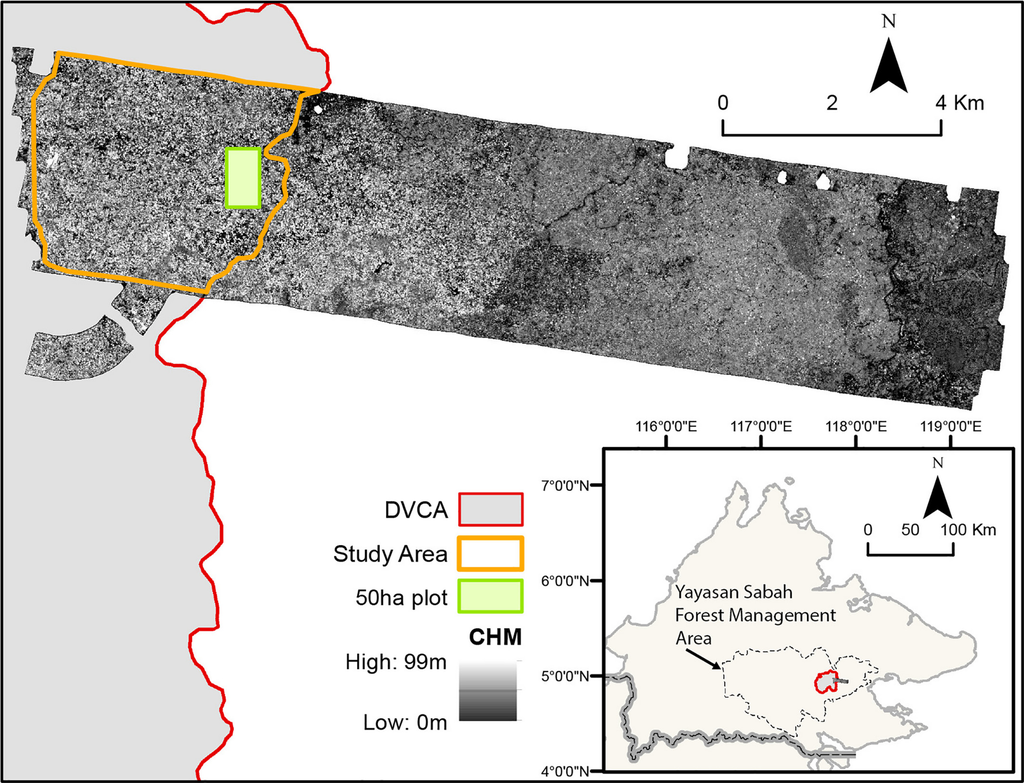

**Figure 1**

Location of the remotely sensed data and 50 ha plot in relation to the Danum Valley Conservation Area (DVCA) in Sabah, Malaysia. SFMA, Sabah Forest Management Area. The study area (orange line) as well as the 50‐ha plot (green rectangle) are indicated. The Canopy Height Model (CHM) is used to represent the extent of the remotely sensed data.

### Occupied airborne data collection

Occupied (or manned) airborne hyperspectral and LiDAR data were collected concurrently by the UK Natural Environmental Research Council’s Airborne Research Facility (NERC‐ARF) in November 2014. The data were captured from a Dornier 228–201, flying at 65.6–71.6 ms<sup>−1</sup> at an altitude of 2335–2429 m. In total 10 flightlines were flown, on bearings of 100 or 280°, surveying an area of ~2083 ha of primary forest (Fig. 1).

LiDAR data were captured using a Leica ALS50‐II which operates with an 8W class 4 laser with radiation at 1064 nm. The sensor is capable of recording up to four discrete returns for each emitted pulse. The footprint of the pulse on the ground is approximately 22 cm when fired from an altitude of 1000 m. The dataset has a point density ranging between 2.80 and 3.16 per m<sup>2</sup>. The data were processed to produce a top‐of‐Canopy Height Model (CHM), with a spatial resolution of 1 m<sup>2</sup>, based on the difference between the Digital Surface Model (DSM) and the Digital Elevation Model (DEM) using LAStools software (Isenburg, 2014).

where *p<sub>pc</sub>* is the value for each pixel within each of the eight principal component layers.

### Liana canopy cover survey

Data on liana canopy cover were collected in 2017 and 2018 for training of a neural network classification (*n* = 454 trees). The LiDAR data were uploaded to a tablet computer (Apple) connected to a GPS receiver (Garmin GLO 2; GARMIN) so individual tree crowns could be visually delineated in the field using the GeoEditor application (MapTiler). As a result, error associated with GPS accuracies can be avoided. To minimise error associated with estimating liana canopy cover, effort was taken to ensure each tree crown was thoroughly and accurately assessed by; (1) only recording tree crowns that were identified on the canopy height model with a high degree of certainty, (2) making sure tree crowns were fully sun‐lit and completely unobscured from above and (3) having a minimum of two people independently estimating the percentage of a tree crown infested with lianas to the nearest 5% and then mutually agreeing on a final estimate (*cf*. Marvin et al., 2016).

### Tree crown segmentation

The CHM was segmented using the *meanshift* algorithm in the Orfeo Toolbox (OTB) within QGIS v3.6.0 (QGIS Development Team, 2018). The segmentation output consisted of a set of contiguous and non‐overlapping objects. The *meanshift* algorithm was controlled by three main parameters: scale, radius and threshold. We performed a grid‐search using four different values for each parameter (Table S1). A total of 64 segmentations were produced using each parameter combination (Table S2). It is not possible to know, prior to segmentation, which combination of values will produce the optimal segmentation, therefore a large range of values were chosen for each parameter to ensure the optimal parameter combination was captured. Following this, a second grid search was performed which inspected an additional 27 combinations (Table S3). Each segmentation result was submitted to a supervised accuracy assessment. Among the many methods available (Costa et al., 2018), the Segmentation Evaluation Index (SEI) (Yang et al., 2015) was selected to provide an estimate of the accuracy of the segmentation. SEI is a strict measure as it requires a one‐to‐one correspondence between the segments and reference polygons. This is a desirable feature in the context of this study as one object should correspond to just one tree and vice versa. If not, the segmentation accuracy is penalised (Costa et al., 2018). The 91 segmentations were compared against a reference set of 124 tree boundaries across the study area manually delineated using the CHM. SEI values ranged from 0.276 to 0.818, corresponding to the best and worse results, respectively. The smallest SEI value was derived from the parameter combination: scale = 15, radius = 5 and threshold = 0.005 (Table S3). The segmentation produced with this parameter combination was used in the subsequent analysis.

### Hyperspectral data extraction

When assessing liana canopy cover from the ground, it is only possible to estimate liana infestation for entire tree‐crowns (objects). A more detailed assessment of liana infestation within a tree crown can be achieved by visually dividing the crown into quadrants (*cf*. Marvin et al., 2016). In either case, estimates of liana infestation when assessed from the ground cannot be achieved at the same scale of the hyperspectral pixels. To overcome this, we derived end‐member spectra from trees without lianas in their canopy (therefore ‘tree’) and trees with highly liana infested (≥75%) canopies (therefore ‘liana’) to explain the spectral range (Plaza et al., 2012). As such, each hyperspectral pixel within the object relates to a pure cover of either tree or liana leaves. To allow comparison with the object‐based approach, we derived end‐member spectra for both approaches (Fig. 2). For the object‐based classification, end‐member spectra were extracted from the segmented hyperspectral imagery for the same trees used in the pixel‐based classification (*n* = 267 trees/8827 pixels; Table 1). This yielded a total of 7826 hyperspectral pixels (226 trees) with no liana infestation and 1001 hyperspectral pixels (41 trees) with highly liana‐infested canopies (see, Table 1).

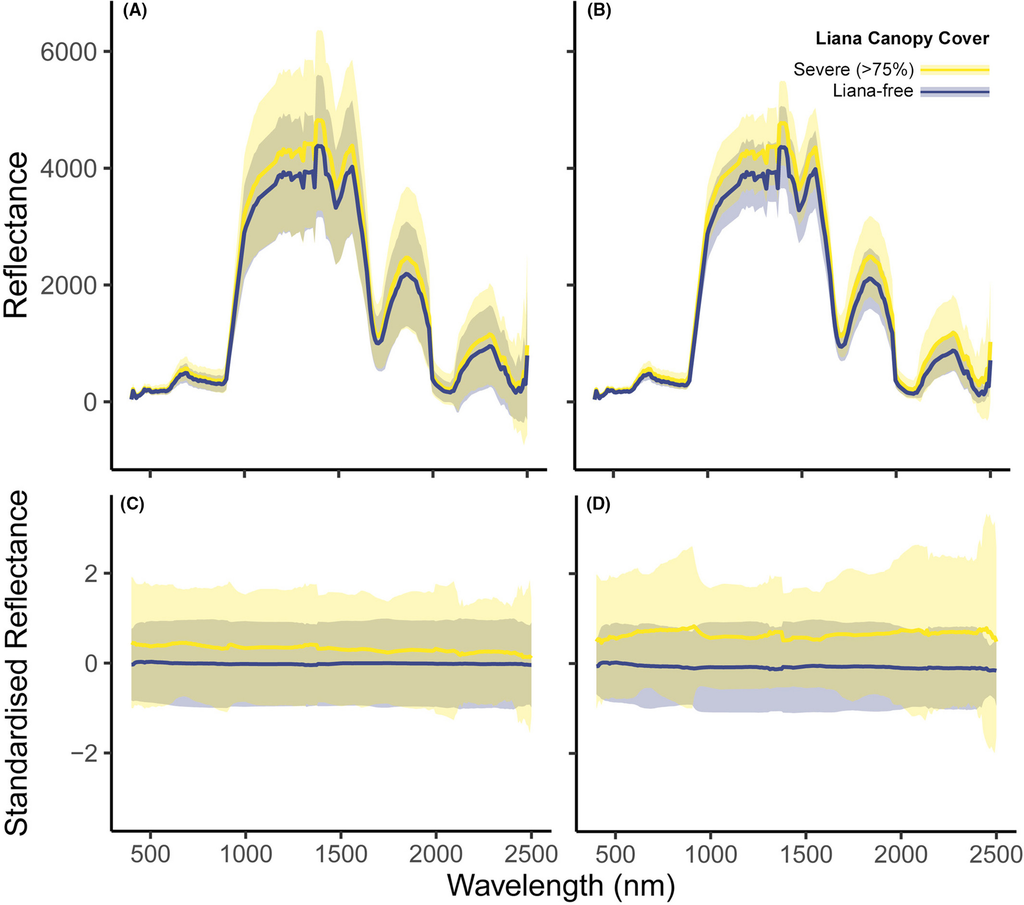

**Figure 2**

Spectral reflectance of liana‐free trees and trees highly infested with liana leaves using ground‐based training data. (A and B) Average reflectance values for pixel‐ and object‐based approaches, respectively. (C and D) Standardised reflectance values for pixel‐ and object‐based approaches, respectively. Standardised (*μ* = 0, *σ* = 1) reflectance shows the difference across all bands by removing the magnitude of reflectance. Lines are mean reflectance values for all trees (shading ± 1 SD). Blue lines represent liana‐free trees (n<sub>trees</sub> = 226, n<sub>pixels</sub> = 7826), yellow lines represent trees highly infested with liana leaves (n<sub>trees</sub> = 41, n<sub>pixels</sub> = 1001).

Table 1. Data used for the training of neural network models and validation of predicted liana infestation maps.

[output not shown]

- EMs, Endmembers; values within [ ] indicate proportional coverage of liana infestation in the tree crown. Balanced EMs contain an equal number of data points within each class. Numbers in bold refer to totals.

Where the crown delineation derived from the CHM overlapped more than one object in the segmented hyperspectral imagery, we assigned a weight based on the proportion of each segmented object that made up the area as defined by the delineated crown boundaries. All weights were normalised to add up to one and used to calculate a weighted mean by multiplying the spectral values of a segmented object with the associated weight.

### Neural network modelling

Prior to training the neural network model, the liana‐free and severely liana‐infested data were balanced by randomly removing pixels without liana infestation to ensure there was an equal number of data points within each input class (i.e., 1001 pixels for each class). The pixels for each class were then randomly split into 80% for training (801 pixels) and 20% for verification (200 pixels) (Olson et al., 2018).

We recognise that liana canopy cover estimates may have changed during the time lag (2.5–3.5 years) between airborne data acquisition and liana canopy cover surveys. Subsequently, both an increase and decrease in liana infestation may have occurred during this time. For example, the formation of a new canopy gap would be prone to rapid liana colonisation. While knowledge on the temporal dynamics of liana infestation is scarce, two studies—one in a seasonal (Ingwell et al., 2010) and one in an aseasonal forest (Wright et al., 2015)—give some insights into the size of the change in liana infestation that can be expected. A study conducted in an aseasonal forest in peninsular Malaysia revealed that 2% of trees that had no liana infestation had become severely (≥75%) liana infested, and vice versa, over a 12‐year period (Wright et al., 2015). The change in the seasonal forest was greater, with Ingwell et al. (2010) observing that 5.3% of trees had changed from no liana infestation to severely (≥75%) liana infested; and 10.9% of trees had changed from severely liana infested to no liana infestation over a 10‐year period. The difference between the two studies can be explained by the rapid growth, and the growth advantage, of lianas over trees in seasonal forests (Schnitzer et al., 2019). Although these data show that it is unlikely that substantial changes in liana infestation would have occurred over a 3.5‐year time frame, we nevertheless accounted for a potential large difference in liana canopy cover estimates by applying noise to the input data that represented the same degree of change observed by Ingwell et al. (2010). To incorporate a similar size error as in Ingwell et al. (2010), we randomly selected 42 pixels or 2 trees (5.3% of the input data, pixels or objects respectively) from the class with no liana infestation and classified them as severely liana infested. Similarly, we randomly selected 87 pixels or 4 trees (10.9% of the input data, pixels or objects, respectively) from the class with severe liana infestation and classified them as liana‐free.

The neural network model was run 100 times and after each iteration the model was applied to the entire study landscape. With each iteration we randomly (1) removed pixels from the no liana infestation class to ensure each input class was balanced, (2) split data for training and verification and (3) reclassified a proportion of the input data to account for differences in liana canopy cover estimates over time (as above). The final landscape scale liana infestation output is an average of all 100 neural network iterations. Averaging multiple models improves generalisation and also allows the calculation of uncertainty estimates based on the standard deviation of all predictions (Lu et al., 2008). To assess the level of uncertainty across predictions, we regressed the standard deviation for predicted values, from 100 runs of the neural network, against liana infestation.

Separately to this, we also assessed the maximum degree of error which could be applied to the input data without a significant loss in the accuracy of predicted liana infestation. We incrementally increased error in the input data from 0% to 50% over 100 neural network model iterations to assess the effect of input data inaccuracies on the neural network model error and classification accuracy. An incremental increase of noise in the input data with each iteration of the neural network revealed a steady increase in the neural network sum of squared error (Fig. S4). However, the ability of the neural network to generalise is maintained up to 30% error in the input data as shown by the accuracy of model predictions in relation to a verification dataset. The use of input data with 16% error, as observed by Ingwell et al. (2010), shows to have little impact on the accuracy of predicted liana infestation.

### Accuracy assessment of predicted outputs

Following good practice for accuracy assessment (Olofsson et al., 2014; Stehman & Foody, 2019), we used an independent dataset of trees (*n* = 168) collected in a random distribution from within the 50 ha plot to assess the accuracy of the predicted map (Fig. 1; Table 1). We used a weighted mean approach (see Section 2.5) to account for cases where tree crown boundaries of segmented objects did not match perfectly with crown boundaries delineated using the CHM in the field. To validate the pixel‐based classification, we averaged predicted liana infestation values for individual pixels inside the delineated crown boundaries to derive liana canopy cover estimates at the tree level.

which represents the mean deviation of predicted from observed values (i.e., with respect to the 1:1 line) (Piñeiro et al., 2008). Assessing the accuracy of model predictions imposes special interest in the 1:1 line of equality, *Y* = *X*. Unlike the root mean squared error (RMSE) which estimates the mean deviation of predicted values from the regression line of predicted vs observed values, the RMSD calculates the deviation of each predicted value against the 1:1 line (Gauch et al., 2003). Subsequently, RMSE will always be smaller and thus an underestimation of the error between observed and predicted values (Piñeiro et al., 2008). The units of RMSD correspond to the same units as the model variable under evaluation, in this case the percentage of liana infestation.

We accounted for error associated with observational uncertainty in liana canopy cover estimates as well as temporal change applied in model training. We quantified observational error by assessing the difference between estimates of liana canopy cover derived from two observers. The mean difference in estimates were used to obtain a small and gross observational uncertainty (Fig. S5). Data revealed that 96% of trees contained a small error of 5% and 4% of trees contained a large error of 30% (Fig. S5). Error derived from temporal change was also applied whereby 8% of trees had an error of 75% (see Data S1, section 1.6). Observed liana canopy cover values were entered into Monte Carlo (MC) simulations. Random values were generated from a t‐distribution with a variation that encompassed the three levels of error (i.e., 5%, 30% and 75%). Using this approach we generated 100 random values which could be used to assess each of the 100 predicted liana infestation maps.

We also degraded outputs to an ordinal scale by partitioning predicted liana infestation into three groups as follows: neural network membership values equal to or below 0.3 were set to ‘low’, values between 0.31 and 0.69 were set to ‘medium’ and values equal to or greater than 0.7 were set to ‘high’. We produced a confusion matrix using predicted and reference liana infestation grouped in three classes. We used overall accuracy and Area Under the Curve (AUC) to assess the accuracy of predicted values. To test for significant differences between pixel‐ and object‐based approaches we used a McNemar test to assess the level of consistency between the two model outputs. A 0.05 significance level was used. All analyses were conducted in R v3.5.1 (R Core Team, 2019).

## Results

### Spectral difference between liana‐free and highly liana infested trees

We found spectral differences between liana‐free trees and trees highly infested with lianas for both pixel‐ (Fig. 2A and C) and object‐based approaches to the classification (Fig. 2B and D). While the principal components were used to train the neural network model, the full spectral reflectance indicates regions of the spectra with the greatest difference between liana‐free and severely liana infested trees. Furthermore, standardised reflectance removes the signal of reflectance magnitude making these differences more apparent. The spectral reflectance for severely liana‐infested trees was greater across all spectral bands in comparison to liana‐free trees (Fig. 2C and D). The regions of the spectra that were most efficient for distinguishing lianas from trees peaked in the visible (546–574 nm) and near‐infrared (893–916 nm) for pixel‐ and object‐based approaches, respectively.

### Predicted and observed liana canopy cover

A scatterplot of observed and predicted liana infestation revealed a better fit with a pixel‐based approach (RMSD = 27.0% ± 0.80; Fig. 3A) compared to an object‐based approach (RMSD = 32.6% ± 4.84; Fig. 3B). However, the accuracy of predicted liana infestation when partitioned into three classes [≤30%, 31%–69%, ≥70%] did not differ between pixel‐ and object‐based approaches (McNemar’s *χ*<sup>2</sup> = 0.211, *P* = 0.65, Table 2).

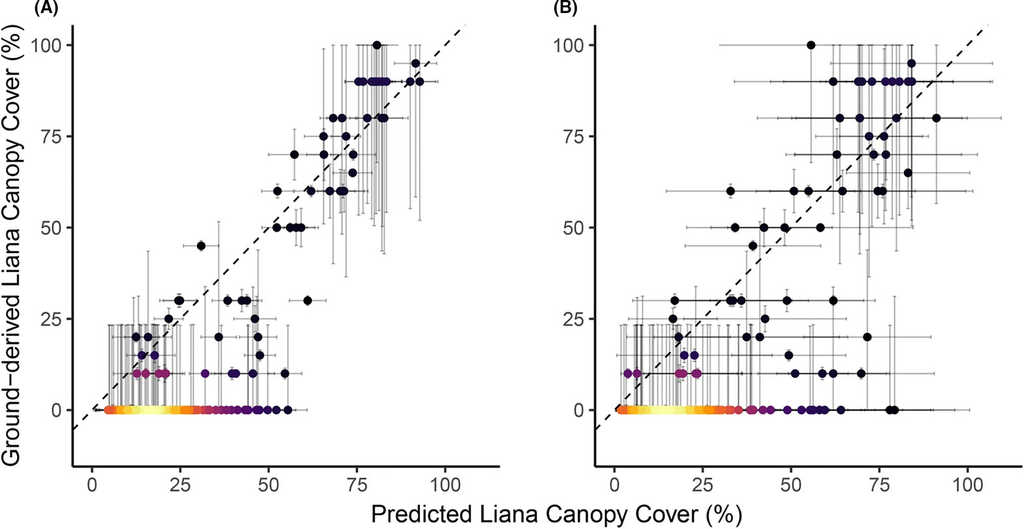

**Figure 3**

Relationship between predicted and ground reference liana canopy cover for (A) a pixel‐based approach and (B) an object‐based approach on a continuous scale. Black dashed line represents a 1:1 line. Coloured points correspond to the density of points, ranging from purple to white with an increasing number of overlapping points. Horizontal error bars represent the standard deviation of 100 predicted values generated from multiple iterations of the neural network model. Vertical error bars represent the standard deviation of 100 randomly generated liana canopy cover values using Monte Carlo simulations.

Table 2. Accuracy assessment of pixel‐ and object‐based model outputs.

| Model output | Classification | AUC | Accuracy (95% CI) | RMSD |
| --- | --- | --- | --- | --- |
| No error applied to validation data |  |  |  |  |
| Output P | Pixel | 0.88 | 0.78 (0.71–0.84) | 20.5 |
| Output O | Object | 0.84 | 0.70 (0.63–0.77) | 25.1 |
| Error applied to validation data over 100 runs |  |  |  |  |
| Output P | Pixel | 0.74 ± 0.03 | 0.71 ± 0.02 | 27.0 ± 0.80 |
| Output O | Object | 0.68 ± 0.19 | 0.61 ± 0.18 | 32.6 ± 4.84 |

- AUC, area under the curve; RMSD, root mean squared deviation.

### Model outputs and uncertainty

Both pixel‐ and object‐based approaches produced similar patterns of predicted liana infestation across the landscape (Fig. 4A). An increase in liana infestation was generally associated with a decrease in canopy height (Fig. S1). The use of multiple neural network models allowed for a calculation of uncertainty around overall predictions (Fig. 5). We found a pixel‐based classification to predict liana infestation with less uncertainty in comparison to an object‐based classification (Figs. 3 and 5).

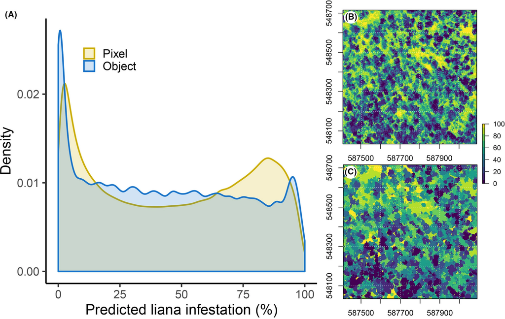

**Figure 4**

Predicted liana infestation showing (A) the distribution of values for a pixel‐ (yellow line) and object‐based (blue line) classifications, as well as the model predictions for a section of the study area for (B) pixel and (C) object‐based classifications, respectively.

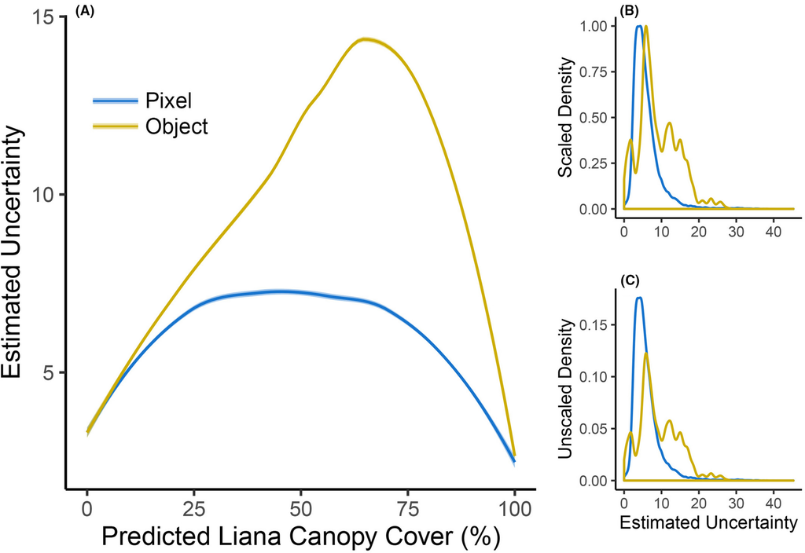

**Figure 5**

Estimated uncertainty for both model outputs. (A) shows the relationship between estimated uncertainty and predicted liana infestation, (B) and (C) show the scaled and unscaled frequency of uncertainty values across the study area, respectively. Estimated uncertainty was calculated based on the standard deviation of predicted values over 100 neural network models. Fitted lines are produced using a local regression (loess) with 95% confidence interval. Note, the confidence intervals are not visible due to the large sample size.

## Discussion

Here, we show, for the first time, that despite a lower spectral contrast between liana‐free and highly liana infested tree crowns compared to seasonally dry forests (Castro‐Esau et al., 2004; Marvin et al., 2016; Sánchez‐Azofeifa et al., 2009), airborne remotely sensed imagery and a neural network machine learning classification can be used to assess liana infestation at a landscape‐level across an aseasonal forest. Our work therefore extends previous research using similar methodologies to predict liana infestation in seasonally dry forests (Foster et al., 2008; Li et al., 2018; Marvin et al., 2016).

Additionally, we utilised two different approaches in an attempt to overcome some of the methodological issues associated with a difference in scale between remotely sensed data and canopy observations of liana infestation. A pixel‐based classification approach revealed a stronger relationship with reference data (RMSD = 27.0% ± 0.80) in comparison with an object‐based approach (RMSD = 32.6% ± 4.84; Fig. 3). Furthermore, a pixel‐based approach revealed less variation in predictions compared to an object‐based approach (Fig. 5).

While the change in spatial units from pixels to objects reduced within‐class spectral variation (Fig. 2), error associated with under‐segmentation, that is objects that cover more than one class, may have resulted in large differences in predictions for segmented objects (Liu & Xia, 2010). The overall effects of both over‐ and under‐segmentation present a key limitation for object‐based classifications. Therefore, while utilising the entire tree canopy may offer a more attractive approach in theory, the success of this approach, in dense tropical forests, depends greatly on the segmentation process to accurately define objects.

We found a noticeable over‐prediction of liana canopy cover for observed estimates below 30% infestation (Fig. 3). This finding is similar to others that have found greater error in the discrimination of tree crowns with liana coverage below 25% ‐ 40% from tree crowns with no liana infestation (Kalacska et al., 2007; Marvin et al., 2016). Where liana infestation is low or absent in a tree canopy, spectral reflectance contaminated by exposed branches, epiphytes or tree trunks may affect the prediction of liana infestation.

Several other factors may have influenced the accuracy of predicted liana infestation in this study. First, we often observed tall, emergent dipterocarps to be liana‐free. However, the accuracy of liana infestation estimates may be reduced when assessing tall canopy and emergent trees from the ground due to the greater distance between the observer and tree crown (Waite et al., 2019). As a result, error in liana canopy cover estimates for tall trees may have been introduced in the training data which could affect the accurate prediction of liana infestation. In such cases, or when trees are obscured, unoccupied aerial vehicles have proven to be an effective tool for accurate liana infestation assessment (Waite et al., 2019). Furthermore, tall dipterocarps which typically have large, emergent crowns will likely mask liana infestation in tree canopies directly beneath. Liana infestation of the upper canopy, as assessed by an airborne platform, may therefore underestimate the amount of liana infestation in the forest canopy as a whole.

Our findings have demonstrated that remote sensing technologies are capable of accurately detecting liana infestation across an aseasonal tropical forest. As the spectral response of lianas in comparison to trees (Fig. 2) closely resembled results derived from seasonal forests (Marvin et al., 2016), this method may be broadly applicable to other forest locations and types. The approaches used in this study also revealed limitations, suggesting certain approaches may be more suited to one environment over another. For example, the accuracy of segmentation is critical for an object‐based approach, which may only be achievable in a primary forest, where there is greater heterogeneity in the canopy in comparison to logged forests (Numata et al., 2006). In secondary forests, where tree and canopy dimensions are typically more homogenous, a pixel‐based approach may be more suitable. In addition, the requirement for a liana infestation output may guide the decision to adopt a pixel‐ or object‐based approach. The use of an object‐based liana infestation output may be more relatable for forest managers or conservationists that are interested in locating specific trees which are liana‐free or heavily liana infested. Similarly, monitoring change in liana infestation over time, or assessing tree mortality as a result of liana infestation, may favour an object‐based approach as change is interpreted at the tree‐level. However, relating liana infestation to an above ground biomass map or species diversity may benefit from a pixel‐based approach, to allow estimates to be generated at scales which can be aligned for meaningful comparisons.

## Conclusion

The assessment of liana infestation at the landscape scale is essential to understand the mechanisms that drive spatial patterns of liana coverage, monitor changes over time and quantify the impact on carbon storage and sequestration. By combining airborne hyperspectral and LiDAR data with a neural network classification approach, we have demonstrated the ability to detect and assess liana infestation in an aseasonal tropical environment, where the spectral contrast between lianas and trees is low. Due to potential limitations in the accurate segmentation of tree canopies required for an object‐based approach, a pixel‐based classification revealed a higher accuracy in predicting liana infestation at a landscape‐level. This study advances our ability to assess spatial patterns of liana infestation at the landscape‐level, particularly for high (>50%) liana infestation where the impact on carbon storage and sequestration is more pronounced. Being able to detect liana infestation in a tropical forest landscape provides a valuable tool for targeted conservation action and effective forest management focused on liana assessment and control.

## Acknowledgements

The authors thank all the research assistants and staff at Danum Valley as well as supporting agencies Sabah Biodiversity Center, Danum Valley Management Committee, Sabah Forestry Department and the Chief Minister’s Department Office of Internal Affairs & Research for providing logistical support. The authors also thank Sebastian Böck for providing R code used for segmentation accuracy assessment and Liam Clark for the pre‐processing of hyperspectral imagery.

The authors also thank the Natural Environment Research Council [NE/P004806/1 to MEJC, DSB, GMF, GMFvdH; NE/I528477/1 (ARSF MA14/11) to MEJC, DSB, GMF and NE/L002604/1 to CJC, GMF, GMFvdH]. The FCT (Fundação para a Ciência e a Tecnologia) under the project UIDB/04152/2020 – Centro de Investigação em Gestão de Informação (MagIC) to HC. The authors also thank the University of Nottingham for an Anne McLaren Research Fellowship to GMFvdH which funded the collection of the ground data.

## Author Contributions

CJC, GMFvdH, DSB and GMF designed the research. CJC collected ground‐derived liana canopy cover data. HC performed image segmentation and its respective accuracy assessment. CJC led the writing of the manuscript. All authors contributed critically to the draft manuscripts and gave final approval for publication.

## References

[figure not shown]

[Early View](https://zslpublications.onlinelibrary.wiley.com/toc/20563485/0/0)

Online Version of Record before inclusion in an issue

### Details

  This is an open access article under the terms of the [Creative Commons Attribution](http://creativecommons.org/licenses/by/4.0/) License, which permits use, distribution and reproduction in any medium, provided the original work is properly cited.

### Research funding

  - Natural Environment Research Council. Grant Numbers: NE/P004806/1, NE/I528477/1, NE/L002604/1
  - University of Nottingham

### Keywords

  - [Hyperspectral imaging](https://zslpublications.onlinelibrary.wiley.com/action/doSearch?field1=Keyword&text1=Hyperspectral%20imaging)
  - [liana infestation](https://zslpublications.onlinelibrary.wiley.com/action/doSearch?field1=Keyword&text1=liana%20infestation)
  - LiDAR
  - [neural network](https://zslpublications.onlinelibrary.wiley.com/action/doSearch?field1=Keyword&text1=neural%20network)
  - [pixel‐based soft classification](https://zslpublications.onlinelibrary.wiley.com/action/doSearch?field1=Keyword&text1=pixel%E2%80%90based%20soft%20classification)
  - segmentation

### Publication History

  - Version of Record online: 13 February 2021
  - Manuscript accepted: 14 January 2021
  - Manuscript revised: 19 December 2020
  - Manuscript received: 31 March 2020

back